# Blackjack Analysis

Tatton Hensley

2026-10-08

```r
library(dplyr)
```

```r
library(tidyr)
library(ggplot2)
```

## Introduction

We built this simulation with a core idea, to check win rates and compare expected returns at different score limits for hitting. How we define “hit limit” is a score that the player will no longer receive cards when equal or greater to. This was done by setting up a simulation that primarily outputs whether a hand won, lost, or tied against the dealer and then running that simulation for 50,000 individual hands. We generated 50,000 results for each hit limit from a score of 10 to 21, totaling 600,000 total results. This simulation was designed with several assumptions made. We assumed that aces would always be treated as a score of eleven until your score surpasses 21, at which time any aces in your hand would be decreased to a 1 individually until either your score was under a 21 or you ran out of aces. Another assumption is the lack of ability to split hands. This may effect the results of this study, but it was decided that splitting was outside the scope of this study and may skew our results more if included. It is likely deserving a study of its own. Built into the simulation is a shoe made up of 8 decks, which is reshuffled when at roughly half played. This does add unnecessary uncertainty to our study, as the results within the same shoe are dependent on one another. We chose to design it this way to simulate blackjack closer, and come up with an overall data set that provides the overarching odds of specific strategies in real world situations, rather than a simulation that gives you perfectly equal odds of drawing any card at any time. We left doubling down out of our data, as it doesn’t provide you with additional data about win rates.

```r
bjsim <- read.csv("C:/Users/tatto/Downloads/R Homework/Blackjack Project/BlackjackSimData.csv")
```

## Overall Rates

```r
wins_counts <- bjsim %>%
  group_by(Hit.limit, Won) %>%
  summarise(Count = n(), .groups = "drop") %>%
  tidyr::pivot_wider(
    names_from = Won,
    values_from = Count,
    values_fill = 0
  )
```

Now we have the winning data isolated.

```r
arrange(wins_counts)
```

```
## # A tibble: 12 × 4
##    Hit.limit  Lost   Tie   Won
##        <int> <int> <int> <int>
##  1        10 29719  2740 17541
##  2        11 28996  2961 18043
##  3        12 27880  3173 18947
##  4        13 26526  3551 19923
##  5        14 25796  3804 20400
##  6        15 25159  4162 20679
##  7        16 24687  4498 20815
##  8        17 24674  4703 20623
##  9        18 25513  4169 20318
## 10        19 28476  3282 18242
## 11        20 32593  2470 14937
## 12        21 41496   571  7933
```

```r
win_calc <- function(data) {
  data %>%
    mutate(win_calc = Won / (Won + Lost + Tie)) %>%
    select(Hit.limit, win_calc)}

loss_calc <- function(data) {
  data %>%
    mutate(loss_calc = Lost / (Won + Lost + Tie)) %>%
    select(Hit.limit, loss_calc)}
win_odds <- win_calc(wins_counts)
loss_odds <- loss_calc(wins_counts)


arrange(win_odds)
```

```
## # A tibble: 12 × 2
##    Hit.limit win_calc
##        <int>    <dbl>
##  1        10    0.351
##  2        11    0.361
##  3        12    0.379
##  4        13    0.398
##  5        14    0.408
##  6        15    0.414
##  7        16    0.416
##  8        17    0.412
##  9        18    0.406
## 10        19    0.365
## 11        20    0.299
## 12        21    0.159
```

```r
arrange(loss_odds)
```

```
## # A tibble: 12 × 2
##    Hit.limit loss_calc
##        <int>     <dbl>
##  1        10     0.594
##  2        11     0.580
##  3        12     0.558
##  4        13     0.531
##  5        14     0.516
##  6        15     0.503
##  7        16     0.494
##  8        17     0.493
##  9        18     0.510
## 10        19     0.570
## 11        20     0.652
## 12        21     0.830
```

If we assume an even weight for wins and losses, with a tie being worth zero, you can generate the expected return. This will be how much you expect to make off of every dollar you bet. Later we will see how this data changes when we introduce extra value for wins with a blackjack.

```r
bjsim <- bjsim %>%
  mutate(weight = case_when(
    Won == "Won" ~ 1,
    Won == "Tie"  ~ 0,
    Won == "Lost" ~ -1,
    TRUE ~ NA_real_
  ))
```

Using the weights we assigned , we can find the expected value per dollar of your bet.

```r
ev1 <- bjsim %>%
  group_by(`Hit.limit`) %>%
  summarise(
    EV = mean(weight, na.rm = TRUE),
    n = n(),
    .groups = "drop"
  )
ev1
```

```
## # A tibble: 12 × 3
##    Hit.limit      EV     n
##        <int>   <dbl> <int>
##  1        10 -0.244  50000
##  2        11 -0.219  50000
##  3        12 -0.179  50000
##  4        13 -0.132  50000
##  5        14 -0.108  50000
##  6        15 -0.0896 50000
##  7        16 -0.0774 50000
##  8        17 -0.0810 50000
##  9        18 -0.104  50000
## 10        19 -0.205  50000
## 11        20 -0.353  50000
## 12        21 -0.671  50000
```

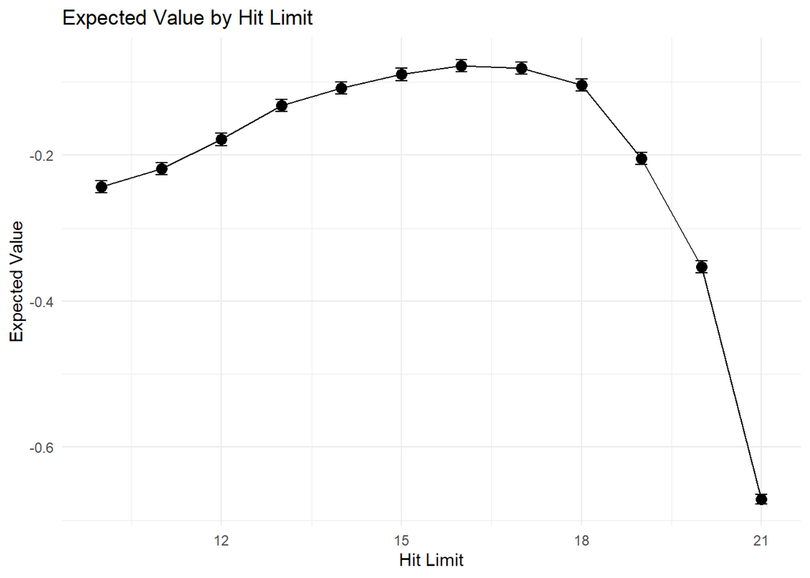

```r
ev_summary <- bjsim %>%
  group_by(`Hit.limit`) %>%
  summarise(
    EV = mean(weight, na.rm = TRUE),
    SD = sd(weight, na.rm = TRUE),
    n = sum(!is.na(weight)),
    SE = SD / sqrt(n),
    Lower = EV - 1.96 * SE,
    Upper = EV + 1.96 * SE,
    .groups = "drop")

ggplot(ev_summary, aes(x = `Hit.limit`, y = EV)) +
  geom_line() +
  geom_point(size = 3) +
  geom_errorbar(
    aes(ymin = Lower, ymax = Upper),
    width = 0.2
  ) +
  labs(
    title = "Expected Value by Hit Limit",
    x = "Hit Limit",
    y = "Expected Value"
  ) +
  theme_minimal()
```

Next we will see how blackjack hands affect the scoring if we weight those wins 3/2.

```r
bjsim <- bjsim %>%
  mutate(weight.bj = case_when(
    Won == "Won" & BJ == "True" ~ 1.5,
    Won == "Won" & BJ == "False" ~ 1,
    Won == "Tie"  ~ 0,
    Won == "Lost" ~ -1,
    TRUE ~ NA_real_
  ))
```

```r
ev2 <- bjsim %>%
  group_by(`Hit.limit`) %>%
  summarise(
    EV = mean(weight.bj, na.rm = TRUE),
    n = n(),
    .groups = "drop"
  )
ev2
```

```
## # A tibble: 12 × 3
##    Hit.limit      EV     n
##        <int>   <dbl> <int>
##  1        10 -0.221  50000
##  2        11 -0.196  50000
##  3        12 -0.155  50000
##  4        13 -0.109  50000
##  5        14 -0.0853 50000
##  6        15 -0.0672 50000
##  7        16 -0.0553 50000
##  8        17 -0.0580 50000
##  9        18 -0.0809 50000
## 10        19 -0.181  50000
## 11        20 -0.330  50000
## 12        21 -0.649  50000
```

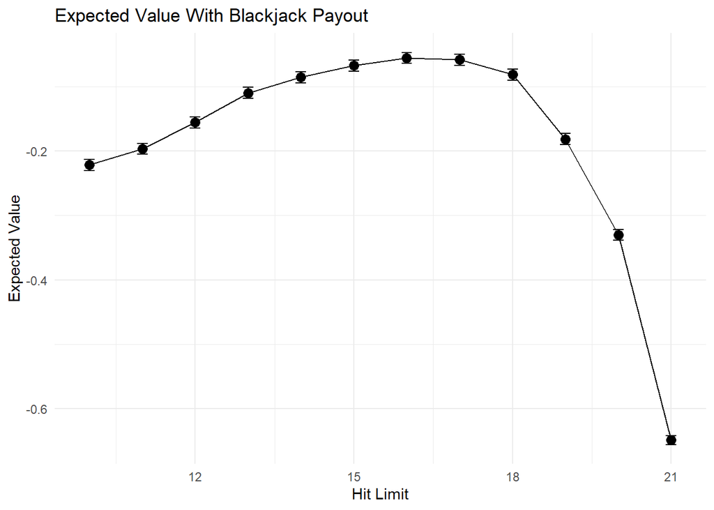

```r
ev_summary2 <- bjsim %>%
  group_by(`Hit.limit`) %>%
  summarise(
    EV = mean(weight.bj, na.rm = TRUE),
    SD = sd(weight.bj, na.rm = TRUE),
    n = sum(!is.na(weight.bj)),
    SE = SD / sqrt(n),
    Lower = EV - 1.96 * SE,
    Upper = EV + 1.96 * SE,
    .groups = "drop")

ggplot(ev_summary2, aes(x = `Hit.limit`, y = EV)) +
  geom_line() +
  geom_point(size = 3) +
  geom_errorbar(
    aes(ymin = Lower, ymax = Upper),
    width = 0.2
  ) +
  labs(
    title = "Expected Value With Blackjack Payout",
    x = "Hit Limit",
    y = "Expected Value"
  ) +
  theme_minimal()
```

There is a notable, though predictably linear, increase in the EV. The mean loss per dollar bet is 5.5c when your betting limit is 16.

## Conditional Win Rates

Next, we should consider what win rates are like when the dealer is showing a specific card.

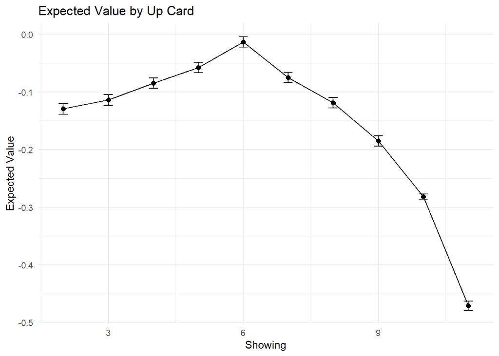

```r
ev_summary3 <- bjsim %>%
  mutate(Showing = if_else(Showing == 1, 11, Showing)) %>%
  group_by(Showing) %>%
  summarise(
    EV = mean(weight.bj, na.rm = TRUE),
    SD = sd(weight.bj, na.rm = TRUE),
    n = sum(!is.na(weight.bj)),
    SE = SD / sqrt(n),
    Lower = EV - qt(0.975, df = n - 1) * SE,
    Upper = EV + qt(0.975, df = n - 1) * SE,
    .groups = "drop"
  )

ggplot(ev_summary3, aes(x = Showing, y = EV)) +
  geom_line() +
  geom_point(size = 2) +
  geom_errorbar(
    aes(ymin = Lower, ymax = Upper),
    width = 0.2
  ) +
  labs(
    title = "Expected Value by Up Card",
    x = "Showing",
    y = "Expected Value"
  ) +
  theme_minimal()
```

```r
ev3 <- bjsim %>%
  mutate(Showing = if_else(Showing == 1, 11, Showing)) %>%
  group_by(Showing) %>%
  summarise(
    EV = mean(weight.bj, na.rm = TRUE),
    n = n(),
    .groups = "drop"
  )
arrange(ev3)
```

```
## # A tibble: 10 × 3
##    Showing      EV      n
##      <dbl>   <dbl>  <int>
##  1       2 -0.129   46263
##  2       3 -0.114   46261
##  3       4 -0.0847  45944
##  4       5 -0.0575  46204
##  5       6 -0.0132  46175
##  6       7 -0.0748  46348
##  7       8 -0.119   46479
##  8       9 -0.185   46182
##  9      10 -0.281  183829
## 10      11 -0.471   46315
```

These results are using the 3/2 weighted blackjack wins. The result of an EV of -.013 is significantly better than the surrounding data, but after investigating our methods, I don’t see anything that could be affecting it that strongly.The overall win rates are low, but the highest EVs are on an up card of 4, 5, 6, or 7. If the dealer is showing an ace, your chances of winning fall significantly.

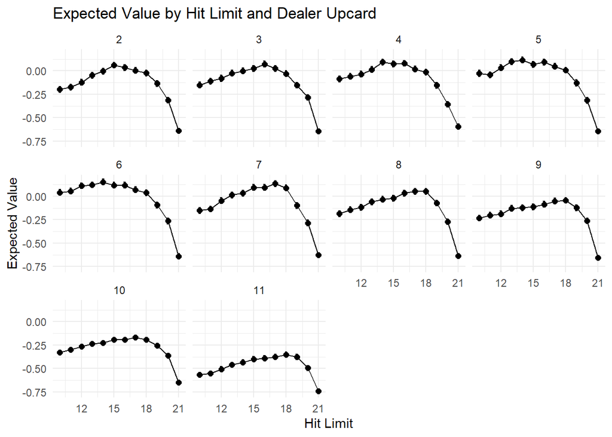

```r
ev_summary4 <- bjsim %>%
  mutate(Showing = if_else(Showing == 1, 11, Showing)) %>%
  group_by(Showing, Hit.limit) %>%
  summarise(
    EV = mean(weight.bj, na.rm = TRUE),
    SD = sd(weight.bj, na.rm = TRUE),
    n = sum(!is.na(weight.bj)),
    SE = SD / sqrt(n),
    Lower = EV - qt(0.975, df = n - 1) * SE,
    Upper = EV + qt(0.975, df = n - 1) * SE,
    .groups = "drop"
  )

ggplot(ev_summary4, aes(x = Hit.limit, y = EV)) +
  geom_line() +
  geom_point(size = 2) +
  geom_errorbar(
    aes(ymin = Lower, ymax = Upper),
    width = 0.2
  ) +
  facet_wrap(~ Showing) +
  labs(
    title = "Expected Value by Hit Limit and Dealer Upcard",
    x = "Hit Limit",
    y = "Expected Value"
  ) +
  theme_minimal()
```

```r
ev4 <- bjsim %>%
  mutate(Showing = if_else(Showing == 1, 11, Showing)) %>%
  group_by(Showing, Hit.limit) %>%
  summarise(
    EV = mean(weight.bj, na.rm = TRUE),
    n = n(),
    .groups = "drop"
  ) %>%
  group_by(Showing) %>%
  slice_max(order_by = EV, n = 1, with_ties = TRUE) %>%
  ungroup()
ev4
```

```
## # A tibble: 10 × 4
##    Showing Hit.limit      EV     n
##      <dbl>     <int>   <dbl> <int>
##  1       2        15  0.0605  3934
##  2       3        16  0.0718  3880
##  3       4        14  0.0941  3854
##  4       5        14  0.116   3862
##  5       6        14  0.151   3764
##  6       7        17  0.134   3838
##  7       8        17  0.0515  3900
##  8       9        18 -0.0439  3914
##  9      10        17 -0.170  15231
## 10      11        18 -0.353   3832
```

The optimal hit limit does seem to fluctuate somewhat based on the card the dealer is showing. They range from 14 to 18 with a majority sitting around 17.

So what is the maximum possible EV if we use the optimal hit limit from each showing card. If we average them out with the weight of a 1/13 chance of any card being the up card, which means a 4/13 chance that a card with the score of 10 is the up card.

```r
overall_ev <- ev4 %>%
  mutate(
    probability = if_else(Showing == 10, 4/13, 1/13)
  ) %>%
  summarise(
    Weighted_EV = sum(EV * probability, na.rm = TRUE)
  )

overall_ev
```

```
## # A tibble: 1 × 1
##   Weighted_EV
##         <dbl>
## 1     -0.0305
```

If you use the optimal hit limits on each dealer up card, you end with a final EV of -.0305, losing 3.1c on every dollar you bet.